# Project 2 - ST 558 - CM Heubusch

# Summarizations

*You should produce some basic (but meaningful) summary statistics about the training data you are working with. The GENERAL things that the plots describe should be explained but, since we are going to automate things, there is no need to try and explain particular trends in the plots you see (unless you want to try and automate that too!).*

## Calculating Summary Statistics for Variables

```r
summary(newsDataTrain)
```

```
##  n_tokens_title  n_tokens_content n_unique_tokens  n_non_stop_words
##  Min.   : 4.00   Min.   :   0.0   Min.   :0.0000   Min.   :0.0000
##  1st Qu.: 9.00   1st Qu.: 246.0   1st Qu.:0.4737   1st Qu.:1.0000
##  Median :10.00   Median : 394.0   Median :0.5427   Median :1.0000
##  Mean   :10.44   Mean   : 539.2   Mean   :0.5307   Mean   :0.9687
##  3rd Qu.:12.00   3rd Qu.: 710.0   3rd Qu.:0.6088   3rd Qu.:1.0000
##  Max.   :18.00   Max.   :7764.0   Max.   :1.0000   Max.   :1.0000
##
##  n_non_stop_unique_tokens   num_hrefs      num_self_hrefs      num_imgs
##  Min.   :0.0000           Min.   :  0.00   Min.   : 0.000   Min.   : 0.000
##  1st Qu.:0.6288           1st Qu.:  4.00   1st Qu.: 1.000   1st Qu.: 1.000
##  Median :0.6938           Median :  8.00   Median : 3.000   Median : 1.000
##  Mean   :0.6732           Mean   : 10.58   Mean   : 3.403   Mean   : 4.506
##  3rd Qu.:0.7551           3rd Qu.: 13.00   3rd Qu.: 4.000   3rd Qu.: 4.000
##  Max.   :1.0000           Max.   :159.00   Max.   :51.000   Max.   :93.000
##
##    num_videos     average_token_length  num_keywords
##  Min.   : 0.000   Min.   :0.000        Min.   : 1.000
##  1st Qu.: 0.000   1st Qu.:4.476        1st Qu.: 6.000
##  Median : 0.000   Median :4.655        Median : 7.000
##  Mean   : 1.329   Mean   :4.533        Mean   : 7.127
##  3rd Qu.: 1.000   3rd Qu.:4.837        3rd Qu.: 9.000
##  Max.   :73.000   Max.   :8.042        Max.   :10.000
##
##  data_channel_is_lifestyle data_channel_is_entertainment data_channel_is_bus
##  Min.   :0.00000           Min.   :0.0000                Min.   :0.0000
##  1st Qu.:0.00000           1st Qu.:0.0000                1st Qu.:0.0000
##  Median :0.00000           Median :0.0000                Median :0.0000
##  Mean   :0.04655           Mean   :0.2053                Mean   :0.1701
##  3rd Qu.:0.00000           3rd Qu.:0.0000                3rd Qu.:0.0000
##  Max.   :1.00000           Max.   :1.0000                Max.   :1.0000
##
##  data_channel_is_socmed data_channel_is_tech data_channel_is_world
##  Min.   :0.00000        Min.   :0.0000       Min.   :0.0000
##  1st Qu.:0.00000        1st Qu.:0.0000       1st Qu.:0.0000
##  Median :0.00000        Median :0.0000       Median :0.0000
##  Mean   :0.05019        Mean   :0.1845       Mean   :0.2087
##  3rd Qu.:0.00000        3rd Qu.:0.0000       3rd Qu.:0.0000
##  Max.   :1.00000        Max.   :1.0000       Max.   :1.0000
##
```

[output cut: 89 more lines]

```
##  Min.   :0.0000     Min.   :-1.00000         Min.   :0.0000
##  1st Qu.:0.0000     1st Qu.: 0.00000         1st Qu.:0.1500
##  Median :0.1000     Median : 0.00000         Median :0.5000
##  Mean   :0.2769     Mean   : 0.06452         Mean   :0.3423
##  3rd Qu.:0.5000     3rd Qu.: 0.13636         3rd Qu.:0.5000
##  Max.   :1.0000     Max.   : 1.00000         Max.   :0.5000
##
##  abs_title_sentiment_polarity     shares                  channel
##  Min.   :0.0000               Min.   :     1.0   Business     :793
##  1st Qu.:0.0000               1st Qu.:   917.2   Entertainment:957
##  Median :0.0000               Median :  1400.0   Lifestyle    :217
##  Mean   :0.1518               Mean   :  3436.0   Other        :628
##  3rd Qu.:0.2500               3rd Qu.:  2700.0   SocialMedia  :234
##  Max.   :1.0000               Max.   :161600.0   Tech         :860
##                                                  World        :973
```

I further explored the data by looking at a correlations plot with the variables I had expressed interest in previously. I divided the variables into different chunks, to make the plots easier to view. I excluded **weekday_is** variables, as I felt they would only be used for the final creation of the reports, as opposed to being involved in the model. I used the code from our notes *(Module 7 - Summarizing Data/Quantitative Summaries)* for this purpose.

## Creating First Correlation Plot with First 10 Variables

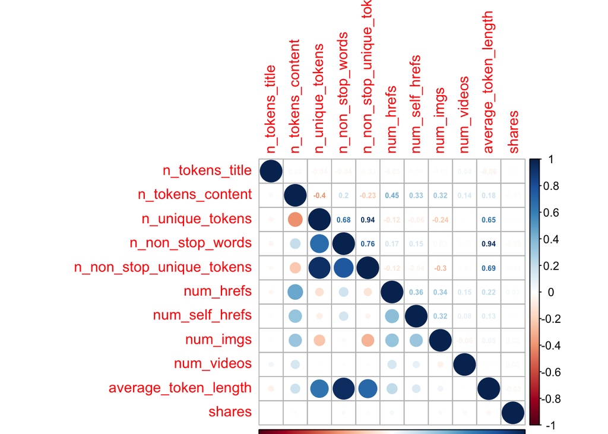

```r
newsCorrelation1 <- cor(newsData[,c(1:10, 59)])
corrplot(newsCorrelation1, type="upper", method="number", tl.pos="lt", number.cex=0.5)
corrplot(newsCorrelation1, type="lower", add=TRUE, tl.pos="n", number.cex=0.5)
```

## Creating Second Correlation Plot with Other Variables

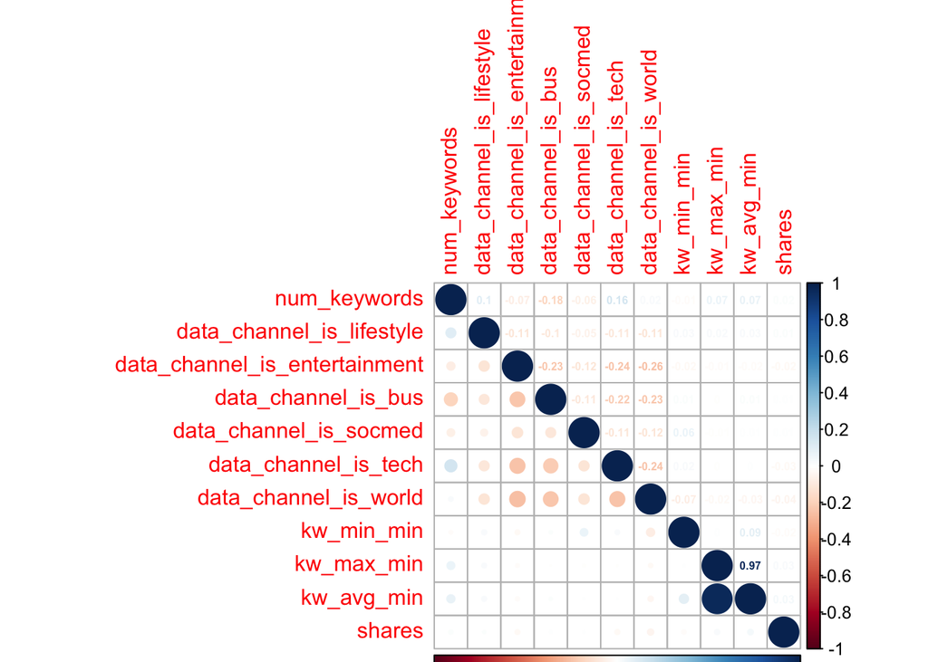

```r
newsCorrelation2 <- cor(newsData[,c(11:20, 59)])

corrplot(newsCorrelation2, type="upper", method="number", tl.pos="lt", number.cex=0.5)
corrplot(newsCorrelation2, type="lower", add=TRUE, tl.pos="n", number.cex=0.5)
```

## Creating Third Correlation Plot

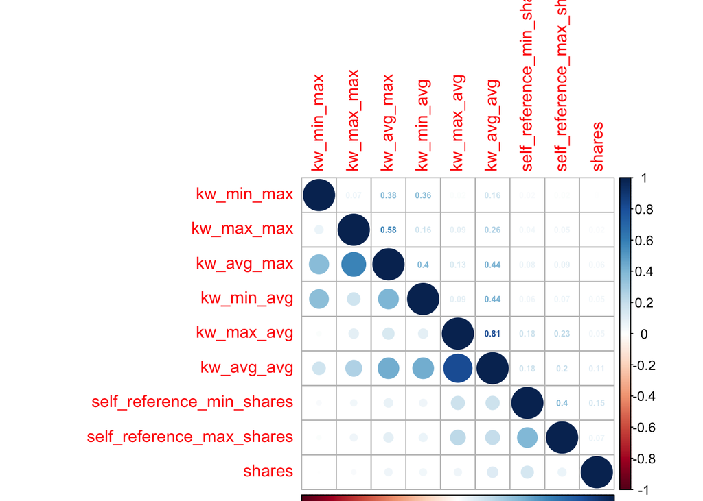

```r
newsCorrelation3 <- cor(newsData[,c(21:28, 59)]) #excluding "weekday_is variables"
corrplot(newsCorrelation3, type="upper", method="number", tl.pos="lt", number.cex=0.5)
corrplot(newsCorrelation3, type="lower", add=TRUE, tl.pos="n", number.cex=0.5)
```

## Creating Fourth Correlation Plot

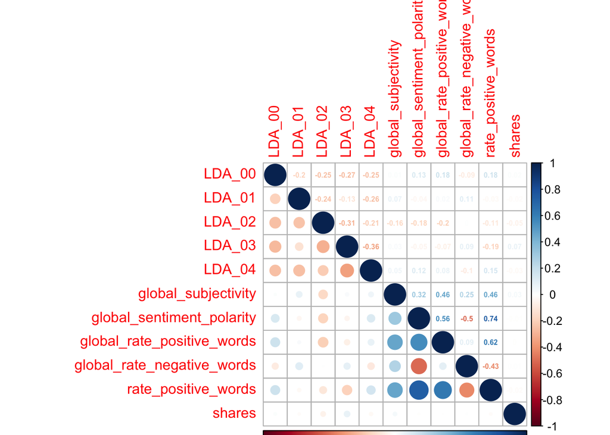

```r
newsCorrelation4 <- cor(newsData[,c(38:47, 59)]) #excluding "weekday_is" variables
corrplot(newsCorrelation4, type="upper", method="number", tl.pos="lt", number.cex=0.5)
corrplot(newsCorrelation4, type="lower", add=TRUE, tl.pos="n", number.cex=0.5)
```

## Creating Fifth Correlation Plot

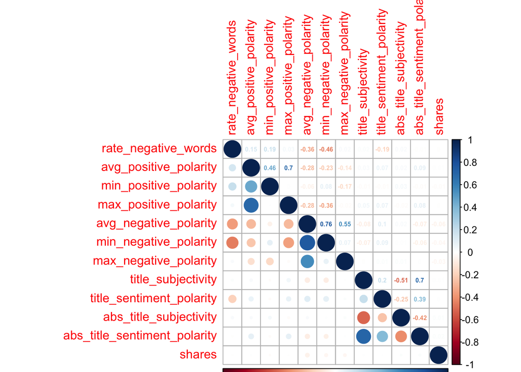

```r
newsCorrelation5 <- cor(newsData[,c(48:58, 59)]) #excluding "weekday_is" variables
corrplot(newsCorrelation5, type="upper", method="number", tl.pos="lt", number.cex=0.5)
corrplot(newsCorrelation5, type="lower", add=TRUE, tl.pos="n", number.cex=0.5)
```

## Creating Extra Correlation Plot

I also created an extra correlation plot, to examine some variables that I had taken an interest in, where I thought there could be relationships between the predictor variables. I thought these would be of interest, as perhaps the number of keywords in the metadata would affect likelihood of someone finding the article through SEO (and then sharing it); or maybe social media users would gravitate towards longer/shorter titles, longer/shorter articles, longer/short words, articles with more negative words, and/or articles that have more links, images, or videos.

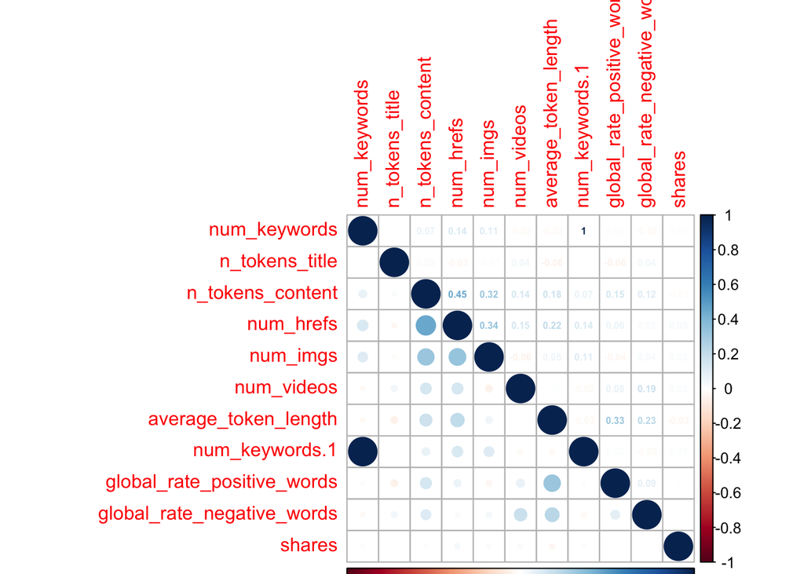

```r
newsCorrelation6 <- cor(newsData[,c("num_keywords", "n_tokens_title","n_tokens_content", "num_hrefs", "num_imgs", "num_videos", "average_token_length", "num_keywords", "global_rate_positive_words", "global_rate_negative_words", "shares")])
corrplot(newsCorrelation6, type="upper", method="number", tl.pos="lt", number.cex=0.5)
corrplot(newsCorrelation6, type="lower", add=TRUE, tl.pos="n", number.cex=0.5)
```

I then created a boxplot showing the shares, classified by the categorical variable of channel that I had created. The summary data (which included all channels) indicated that the median number of shares was around 1400 shares per article, though numerous outliers skew this significantly, so that the mean was 3436 shares. Looking at the plots, there do not seem to be dramatic differences in the data based upon which channel an article has been classified under.

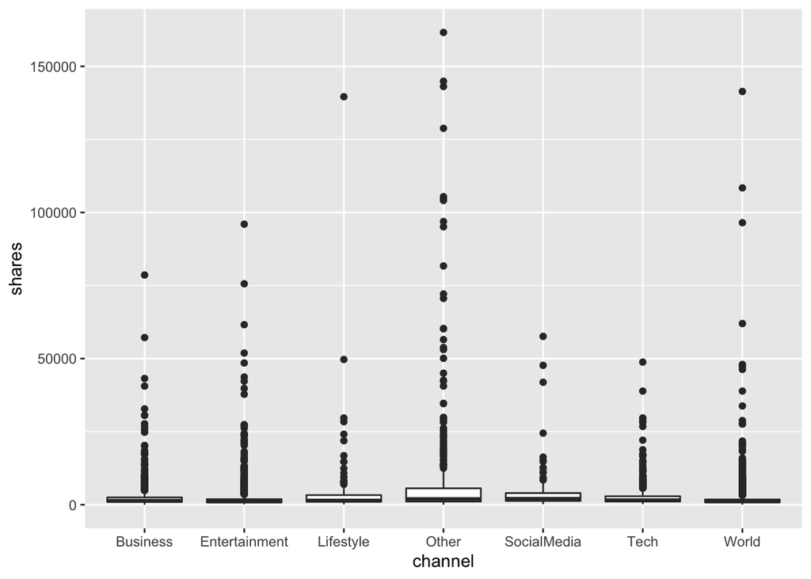

```r
channelsBoxplot <- ggplot(newsDataTrain, aes(x=channel, y=shares))
channelsBoxplot + geom_boxplot()
```

## Creating `ggpairs` Plots

I also created two sets of ggpairs plots, to look at possible relationships in a different way. I again used the variables I looked at in the sixth correlation plot from above.

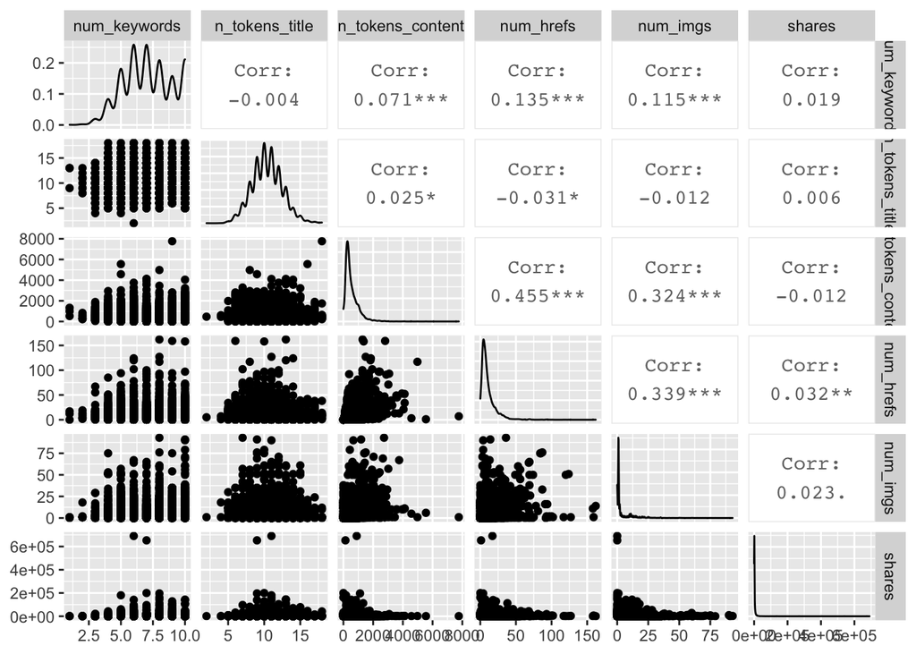

```r
newsData %>% select("num_keywords", "n_tokens_title","n_tokens_content", "num_hrefs", "num_imgs", "shares") %>% ggpairs()
```

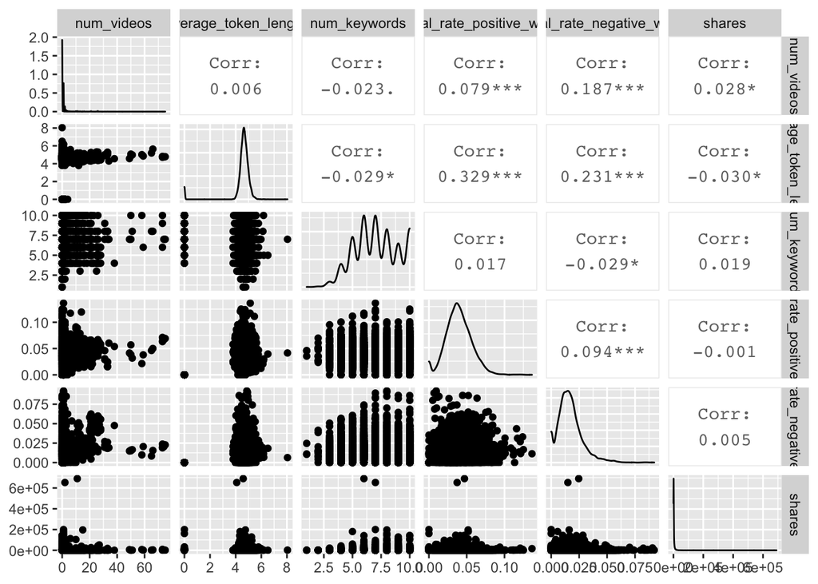

```r
newsData %>% select("num_videos", "average_token_length", "num_keywords", "global_rate_positive_words", "global_rate_negative_words", "shares") %>% ggpairs()
```

# Modeling

## Multiple Linear Regression

To begin, I wanted to first establish a better understanding of what the model would look like if I was to incorporate ALL main effects, excluding any interactions or quadratic terms.

### Creating Model with All Main Effects

```r
dataFitAll <- lm(shares~., data=newsDataTrain)
summary(dataFitAll)
```

```
##
## Call:
## lm(formula = shares ~ ., data = newsDataTrain)
##
## Residuals:
##    Min     1Q Median     3Q    Max
## -12743  -2408  -1176    158 155146
##
## Coefficients: (15 not defined because of singularities)
##                                 Estimate Std. Error t value Pr(>|t|)
## (Intercept)                    4.468e+02  1.776e+03   0.252 0.801393
## n_tokens_title                 1.090e+02  6.260e+01   1.741 0.081668 .
## n_tokens_content              -6.899e-01  4.941e-01  -1.396 0.162657
## n_unique_tokens                2.416e+03  4.229e+03   0.571 0.567824
## n_non_stop_words               2.845e+03  9.089e+03   0.313 0.754279
## n_non_stop_unique_tokens      -3.186e+02  3.570e+03  -0.089 0.928879
## num_hrefs                      2.775e+01  1.579e+01   1.758 0.078794 .
## num_self_hrefs                -4.549e+01  3.944e+01  -1.153 0.248814
## num_imgs                       3.888e+01  2.002e+01   1.942 0.052196 .
## num_videos                    -1.101e+00  3.134e+01  -0.035 0.971964
## average_token_length          -1.366e+03  5.332e+02  -2.562 0.010432 *
## num_keywords                   9.000e+01  8.198e+01   1.098 0.272293
## data_channel_is_lifestyle     -3.347e+03  9.040e+02  -3.702 0.000216 ***
## data_channel_is_entertainment -2.916e+03  5.674e+02  -5.140 2.86e-07 ***
## data_channel_is_bus           -3.779e+03  8.327e+02  -4.538 5.82e-06 ***
## data_channel_is_socmed        -2.871e+03  8.193e+02  -3.504 0.000462 ***
## data_channel_is_tech          -2.772e+03  8.230e+02  -3.369 0.000762 ***
## data_channel_is_world         -2.053e+03  8.216e+02  -2.499 0.012483 *
## kw_min_min                    -3.546e+00  3.051e+00  -1.162 0.245322
## kw_max_min                     1.854e-01  1.354e-01   1.370 0.170830
## kw_avg_min                    -1.221e+00  9.133e-01  -1.337 0.181425
## kw_min_max                    -1.092e-03  2.836e-03  -0.385 0.700257
## kw_max_max                    -4.531e-04  1.071e-03  -0.423 0.672334
## kw_avg_max                    -3.502e-03  1.820e-03  -1.925 0.054340 .
## kw_min_avg                    -6.001e-01  1.672e-01  -3.588 0.000336 ***
## kw_max_avg                    -2.406e-01  5.157e-02  -4.666 3.16e-06 ***
## kw_avg_avg                     2.078e+00  3.072e-01   6.764 1.51e-11 ***
## self_reference_min_shares      1.910e-03  2.099e-02   0.091 0.927520
## self_reference_max_shares     -8.254e-03  1.377e-02  -0.600 0.548828
## self_reference_avg_sharess     2.118e-02  3.225e-02   0.657 0.511359
```

[output cut: 26 more lines]

```
## title_sentiment_polarity       4.309e+01  5.417e+02   0.080 0.936605
## abs_title_subjectivity        -4.686e+02  8.025e+02  -0.584 0.559270
## abs_title_sentiment_polarity   1.313e+03  8.445e+02   1.555 0.120091
## channelEntertainment                  NA         NA      NA       NA
## channelLifestyle                      NA         NA      NA       NA
## channelOther                          NA         NA      NA       NA
## channelSocialMedia                    NA         NA      NA       NA
## channelTech                           NA         NA      NA       NA
## channelWorld                          NA         NA      NA       NA
## ---
## Signif. codes:  0 '***' 0.001 '**' 0.01 '*' 0.05 '.' 0.1 ' ' 1
##
## Residual standard error: 8535 on 4612 degrees of freedom
## Multiple R-squared:  0.06063,    Adjusted R-squared:  0.05065
## F-statistic: 6.075 on 49 and 4612 DF,  p-value: < 2.2e-16
```

## Creating Multiple Linear Regression Model with Only the 16 Significant Predictive Variables

```r
dataFit16 <- lm(shares~n_tokens_title +
        num_imgs +
        average_token_length +
        kw_avg_max +
        kw_max_avg +
        kw_min_avg +
        kw_avg_avg +
        LDA_00 +
        global_subjectivity +
        min_positive_polarity +
        data_channel_is_lifestyle +
        data_channel_is_entertainment +
        data_channel_is_bus +
        data_channel_is_socmed +
        data_channel_is_tech +
        data_channel_is_world,
      data=newsDataTrain)
summary(dataFit16)
```

```
##
## Call:
## lm(formula = shares ~ n_tokens_title + num_imgs + average_token_length +
##     kw_avg_max + kw_max_avg + kw_min_avg + kw_avg_avg + LDA_00 +
##     global_subjectivity + min_positive_polarity + data_channel_is_lifestyle +
##     data_channel_is_entertainment + data_channel_is_bus + data_channel_is_socmed +
##     data_channel_is_tech + data_channel_is_world, data = newsDataTrain)
##
## Residuals:
##    Min     1Q Median     3Q    Max
## -12944  -2317  -1220     34 154668
##
## Coefficients:
##                                 Estimate Std. Error t value Pr(>|t|)
## (Intercept)                   -6.923e+02  1.208e+03  -0.573 0.566662
## n_tokens_title                 1.314e+02  6.126e+01   2.146 0.031964 *
## num_imgs                       2.473e+01  1.598e+01   1.548 0.121728
## average_token_length          -3.080e+02  2.001e+02  -1.539 0.123794
## kw_avg_max                    -2.728e-03  1.236e-03  -2.208 0.027321 *
## kw_max_avg                    -2.175e-01  4.276e-02  -5.086 3.80e-07 ***
## kw_min_avg                    -6.433e-01  1.525e-01  -4.217 2.52e-05 ***
## kw_avg_avg                     2.055e+00  2.752e-01   7.466 9.85e-14 ***
## LDA_00                         2.488e+03  8.700e+02   2.860 0.004253 **
## global_subjectivity            5.931e+03  1.436e+03   4.129 3.71e-05 ***
## min_positive_polarity         -4.452e+03  1.864e+03  -2.389 0.016931 *
## data_channel_is_lifestyle     -2.650e+03  7.102e+02  -3.732 0.000192 ***
## data_channel_is_entertainment -2.935e+03  4.865e+02  -6.034 1.72e-09 ***
## data_channel_is_bus           -3.624e+03  7.334e+02  -4.941 8.05e-07 ***
## data_channel_is_socmed        -2.718e+03  7.405e+02  -3.670 0.000245 ***
## data_channel_is_tech          -2.321e+03  5.233e+02  -4.435 9.40e-06 ***
## data_channel_is_world         -1.863e+03  5.463e+02  -3.411 0.000653 ***
## ---
## Signif. codes:  0 '***' 0.001 '**' 0.01 '*' 0.05 '.' 0.1 ' ' 1
##
## Residual standard error: 8534 on 4645 degrees of freedom
## Multiple R-squared:  0.05428,    Adjusted R-squared:  0.05102
## F-statistic: 16.66 on 16 and 4645 DF,  p-value: < 2.2e-16
```